# Task5

EXPLORATORY DATA ANALYSIS OF A SAMPLE SUPERSTORE

```python
#import all the required libraries
import pandas as pd
import numpy as np
import matplotlib.pyplot as plt
%matplotlib inline
import seaborn as sns
```

```python
#laoding the data
df=pd.read_csv('SampleSuperstore.csv')
df.head()
```

|  | Ship Mode | Segment | Country | City | State | Postal Code | Region | Category | Sub-Category | Sales | Quantity | Discount | Profit |
| --- | --- | --- | --- | --- | --- | --- | --- | --- | --- | --- | --- | --- | --- |
| 0 | Second Class | Consumer | United States | Henderson | Kentucky | 42420 | South | Furniture | Bookcases | 261.9600 | 2 | 0.00 | 41.9136 |
| 1 | Second Class | Consumer | United States | Henderson | Kentucky | 42420 | South | Furniture | Chairs | 731.9400 | 3 | 0.00 | 219.5820 |
| 2 | Second Class | Corporate | United States | Los Angeles | California | 90036 | West | Office Supplies | Labels | 14.6200 | 2 | 0.00 | 6.8714 |
| 3 | Standard Class | Consumer | United States | Fort Lauderdale | Florida | 33311 | South | Furniture | Tables | 957.5775 | 5 | 0.45 | -383.0310 |
| 4 | Standard Class | Consumer | United States | Fort Lauderdale | Florida | 33311 | South | Office Supplies | Storage | 22.3680 | 2 | 0.20 | 2.5164 |

```python
df.describe()
```

|  | Postal Code | Sales | Quantity | Discount | Profit |
| --- | --- | --- | --- | --- | --- |
| count | 9994.000000 | 9994.000000 | 9994.000000 | 9994.000000 | 9994.000000 |
| mean | 55190.379428 | 229.858001 | 3.789574 | 0.156203 | 28.656896 |
| std | 32063.693350 | 623.245101 | 2.225110 | 0.206452 | 234.260108 |
| min | 1040.000000 | 0.444000 | 1.000000 | 0.000000 | -6599.978000 |
| 25% | 23223.000000 | 17.280000 | 2.000000 | 0.000000 | 1.728750 |
| 50% | 56430.500000 | 54.490000 | 3.000000 | 0.200000 | 8.666500 |
| 75% | 90008.000000 | 209.940000 | 5.000000 | 0.200000 | 29.364000 |
| max | 99301.000000 | 22638.480000 | 14.000000 | 0.800000 | 8399.976000 |

```python
df.shape
```

```
(9994, 13)
```

The Postal Code column is not required and there is only one country so the columns can be eliminated

```python
df.drop(['Postal Code','Country'],axis=1,inplace=True)
```

Dropping the duplicate rows

```python
df.drop_duplicates(inplace=True)
```

```python
df.head()
```

|  | Ship Mode | Segment | City | State | Region | Category | Sub-Category | Sales | Quantity | Discount | Profit |
| --- | --- | --- | --- | --- | --- | --- | --- | --- | --- | --- | --- |
| 0 | Second Class | Consumer | Henderson | Kentucky | South | Furniture | Bookcases | 261.9600 | 2 | 0.00 | 41.9136 |
| 1 | Second Class | Consumer | Henderson | Kentucky | South | Furniture | Chairs | 731.9400 | 3 | 0.00 | 219.5820 |
| 2 | Second Class | Corporate | Los Angeles | California | West | Office Supplies | Labels | 14.6200 | 2 | 0.00 | 6.8714 |
| 3 | Standard Class | Consumer | Fort Lauderdale | Florida | South | Furniture | Tables | 957.5775 | 5 | 0.45 | -383.0310 |
| 4 | Standard Class | Consumer | Fort Lauderdale | Florida | South | Office Supplies | Storage | 22.3680 | 2 | 0.20 | 2.5164 |

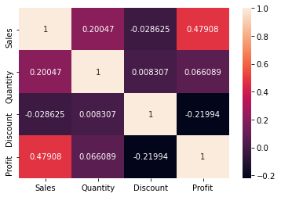

```python
sns.heatmap(df.corr(),annot=True,fmt='.5g')
```

Here we can infer that there is a better correlation og 'Profit' with 'Sales' compared to other factors

We will separate the numerical and Categorical variable as follows

```python
numerical = ['Sales','Quantity','Discount','Profit']
categorical =['Ship Mode','Segment','City','State','Region','Category','Sub-Category']
```

ANALYZING THE NUMERICAL VARIABLES

We can analyze each numerical variable individually using histogram

```
array([[<AxesSubplot:title={'center':'Sales'}>,
        <AxesSubplot:title={'center':'Quantity'}>],
       [<AxesSubplot:title={'center':'Discount'}>,
        <AxesSubplot:title={'center':'Profit'}>]], dtype=object)
```

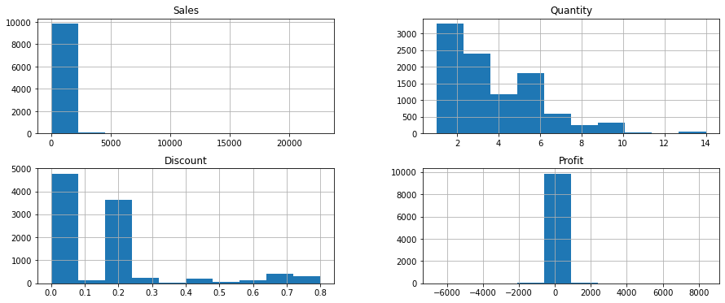

```python
df[numerical].hist(bins=10,figsize=(15,6),layout=(2,2))
```

Categorical variables can be visualized with the help of countplot() using seaborn

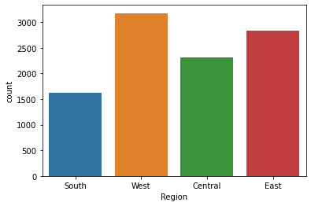

```python
sns.countplot(x='Region',data=df)
```

From the above plot the count is more in western and eastern regions of united states has more demand

Lets take a look of the count for demand according to State wise

```
(array([ 0,  1,  2,  3,  4,  5,  6,  7,  8,  9, 10, 11, 12, 13, 14, 15, 16,
        17, 18, 19, 20, 21, 22, 23, 24, 25, 26, 27, 28, 29, 30, 31, 32, 33,
        34, 35, 36, 37, 38, 39, 40, 41, 42, 43, 44, 45, 46, 47, 48]),
 [Text(0, 0, 'Kentucky'),
```

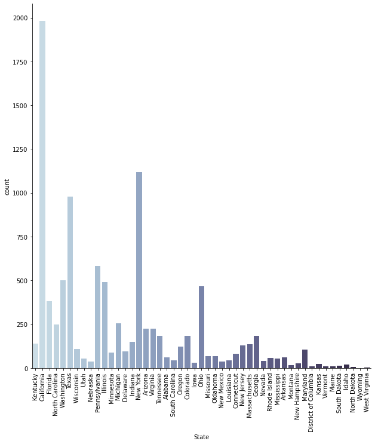

```python
sns.catplot(x='State',kind='count',data=df,palette='ch:s=.25,rot=-.25',height=9,aspect=1)
plt.xticks(rotation=90)
```

Califoria,NewYork,Texas states are in more demand and supplies compared to other states

ANALYZING THE CATEGORICAL VARIABLES

Using count plots we can analyse the individual categorical variables with creating a figure with 2 rows and 4 columns

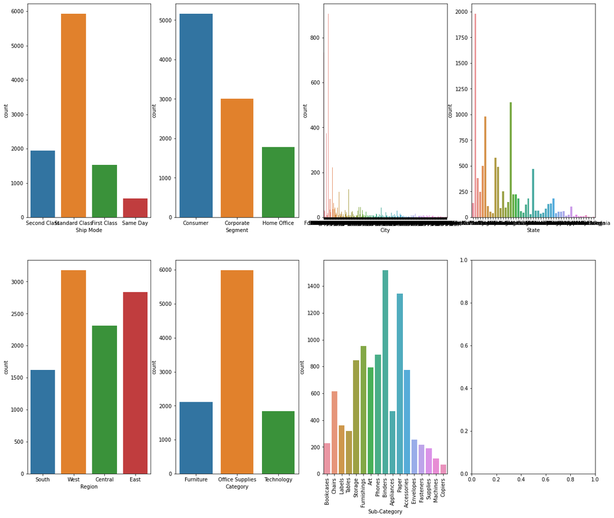

```python
fig,ax =plt.subplots(2,4,figsize=(20,17))
for variables,subplot in zip(categorical,ax.flatten()):
    sns.countplot(x=df[variables],ax=subplot)
for label in subplot.get_xticklabels():
    label.set_rotation(90)
```

Joint plot gives joint distribution and marginal distribution together using seaborn

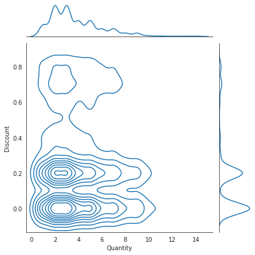

```python
with sns.axes_style('white'):
    sns.jointplot(x='Quantity',y='Discount',data=df,kind='kde')
```

The above plot shows a relation between 'Quantity' and the 'Discount' provided

ANALYZING THE RELATIONSHIP BETWEEN BOTH NUMERICAL AND CATEGORICAL VARIABLES

BASED ON THE QUANTITY :

Most preferred Shipping Mode:

```
        Ship Mode  Quantity
1        Same Day      1956
0     First Class      5675
2    Second Class      7413
3  Standard Class     22684
```

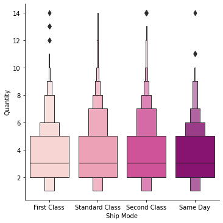

```python
sorted_shipm=df.groupby('Ship Mode')['Quantity'].sum().reset_index().sort_values(by='Quantity',ascending=True)
df_sorted_shipm=pd.DataFrame(data=sorted_shipm)
print(df_sorted_shipm)
sns.catplot(x='Ship Mode',y='Quantity',kind='boxen',data=df.sort_values('Quantity'),palette='RdPu')
```

Highest supplied Category :

```
          Category  Quantity
2       Technology      6932
0        Furniture      8010
1  Office Supplies     22786
```

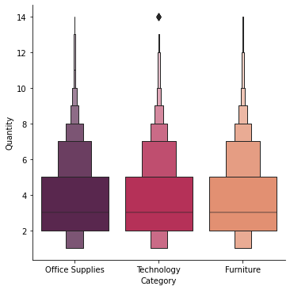

```python
sorted_cq=df.groupby('Category')['Quantity'].sum().reset_index().sort_values(by='Quantity')
df_sorted_cq=pd.DataFrame(data=sorted_cq)
print(df_sorted_cq)
sns.catplot(x='Category',y='Quantity',kind='boxen',data=df.sort_values('Quantity'),legend=True,palette='rocket')
```

Sub-Category in highest demand:

```
   Sub-Category  Quantity
3       Binders      5961
12        Paper      5100
9   Furnishings      3555
13       Phones      3286
14      Storage      3156
2           Art      2986
0   Accessories      2972
5        Chairs      2351
1    Appliances      1729
10       Labels      1387
16       Tables      1241
8     Fasteners       914
7     Envelopes       906
4     Bookcases       863
15     Supplies       647
11     Machines       440
6       Copiers       234
```

```
(array([ 0,  1,  2,  3,  4,  5,  6,  7,  8,  9, 10, 11, 12, 13, 14, 15, 16]),
 [Text(0, 0, 'Paper'),
```

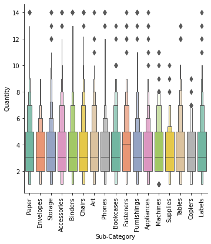

```python
sorted_Sq=df.groupby('Sub-Category')['Quantity'].sum().reset_index().sort_values(by='Quantity',ascending=False)
df_sorted_Sq=pd.DataFrame(data=sorted_Sq)
print(df_sorted_Sq)
sns.catplot(x='Sub-Category',y='Quantity',kind='boxen',data=df.sort_values('Quantity'),legend=True,palette='Set2')
plt.xticks(rotation=90)
```

Top 15 Cities in highest supplied quantities

```
              City  Quantity
329  New York City      3395
266    Los Angeles      2842
374   Philadelphia      1961
438  San Francisco      1910
452        Seattle      1578
207        Houston      1454
80         Chicago      1127
94        Columbus       834
437      San Diego       667
464    Springfield       649
109         Dallas       553
123        Detroit       438
216   Jacksonville       429
330         Newark       362
407       Richmond       336
```

```
(array([ 0,  1,  2,  3,  4,  5,  6,  7,  8,  9, 10, 11, 12, 13, 14]),
 [Text(0, 0, 'Richmond'),
```

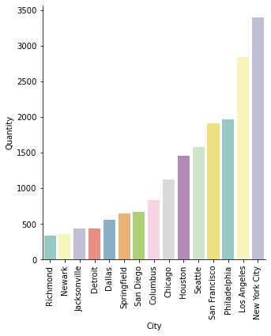

```python
sorted_CC=df.groupby('City')['Quantity'].sum().reset_index().sort_values(by='Quantity',ascending=False)
df_sorted_CC=pd.DataFrame(data=sorted_CC)
df_top15=df_sorted_CC.head(15)
print(df_top15)
sns.catplot(x='City',y='Quantity',kind='bar',data=df_top15.sort_values('Quantity'),palette='Set3')
plt.xticks(rotation=90)
```

Top 15 States in high supplies :

```
             State  Quantity
3       California      7602
30        New York      4202
41           Texas      3710
36    Pennsylvania      2133
45      Washington      1871
11        Illinois      1840
33            Ohio      1757
8          Florida      1379
31  North Carolina       983
20        Michigan       943
44        Virginia       893
1          Arizona       862
9          Georgia       705
4         Colorado       693
40       Tennessee       681
```

```
(array([ 0,  1,  2,  3,  4,  5,  6,  7,  8,  9, 10, 11, 12, 13, 14]),
 [Text(0, 0, 'Tennessee'),
```

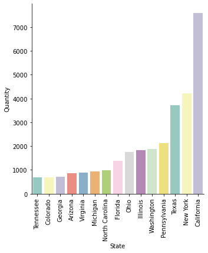

```python
sorted_SQ=df.groupby('State')['Quantity'].sum().reset_index().sort_values(by='Quantity',ascending=False)
df_sorted_SQ=pd.DataFrame(data=sorted_SQ)
df_top15_SQ=df_sorted_SQ.head(15)
print(df_top15_SQ)
sns.catplot(x='State',y='Quantity',kind='bar',data=df_top15_SQ.sort_values('Quantity'),palette='Set3')
plt.xticks(rotation=90)
```

Let's install the altair package for better visualization of categorical and numerical variables

```python
!pip install altair vega_datasets
```

```python
from altair import Row,Column,Color,Scale,Text,Chart
```

Profit Earned by each Category:

```python
profit_cat=df.groupby('Category')['Profit'].sum().reset_index().sort_values(by='Profit')
df_profit_cat=pd.DataFrame(data=profit_cat)
print(df_profit_cat)
altair_df_profit_cat=Chart(df_profit_cat).mark_text().mark_bar().encode(x='Profit',y='Category',
        color='Category').properties(height=200,width=400)
display(altair_df_profit_cat)
```

```
          Category       Profit
0        Furniture   18484.9459
1  Office Supplies  122196.0726
2       Technology  145416.5394
```

[interactive chart not shown]

Most Profitable regions:

```python
profit_r=df.groupby('Region')['Profit'].sum().reset_index().sort_values(by='Profit')
df_profit_r=pd.DataFrame(data=profit_r)
print(df_profit_r)
altair_df_profit_r=Chart(df_profit_r).mark_text().mark_bar().encode(x='Profit',y='Region',color='Profit').properties(height=200,width=400)
display(altair_df_profit_r)
```

```
    Region       Profit
0  Central   39662.0474
2    South   46749.4303
1     East   91471.0909
3     West  108214.9893
```

[interactive chart not shown]

Top 15 Cities with higher profits:

```python
profit_city=df.groupby('City')['Profit'].sum().reset_index().sort_values(by='Profit',ascending=False)
df_profit_city=pd.DataFrame(data=profit_city)
df_top15_profit_city=df_profit_city.head(15)
print(df_top15_profit_city)
altair_profit_city=Chart(df_top15_profit_city).mark_text().mark_bar().encode(x='Profit',y='City',color='City').properties(height=200,width=400)
display(altair_profit_city)
```

```
              City      Profit
329  New York City  62004.5903
266    Los Angeles  30308.4841
452        Seattle  29121.6825
438  San Francisco  17482.9366
123        Detroit  13146.6935
233      Lafayette  10018.3876
215        Jackson   7581.6828
21         Atlanta   6993.6629
300    Minneapolis   6824.5846
437      San Diego   6368.5020
464    Springfield   6200.6974
94        Columbus   5909.1601
330         Newark   5793.7588
93        Columbia   5606.1167
407       Richmond   5567.2486
```

[interactive chart not shown]

Segments with Higher profits:

```python
profit_seg=df.groupby('Segment')['Profit'].sum().reset_index().sort_values(by='Profit')
df_profit_seg=pd.DataFrame(profit_seg)
print(df_profit_seg)
altair_df_profit_seg=Chart(df_profit_seg).mark_text().mark_bar().encode(x='Profit',y='Segment',color='Profit').properties(height=150,width=300)
display(altair_df_profit_seg)
```

```
       Segment       Profit
2  Home Office   60246.8755
1    Corporate   91911.1606
0     Consumer  133939.5218
```

[interactive chart not shown]

Sub-Category Profits and Non-Profits:

```python
profit_SC=df.groupby('Sub-Category')['Profit'].sum().reset_index().sort_values(by='Profit')
df_profit_SC=pd.DataFrame(profit_SC)
print(df_profit_SC)
altair_df_profit_SC=Chart(df_profit_SC).mark_text().mark_bar().encode(x='Profit',y='Sub-Category',color='Sub-Category').properties(height=200,width=400)
display(altair_df_profit_SC)
```

```
   Sub-Category      Profit
16       Tables -17725.4811
4     Bookcases  -3398.7542
15     Supplies  -1189.0995
8     Fasteners    949.5182
11     Machines   3384.7569
10       Labels   5499.1558
2           Art   6511.8388
7     Envelopes   6964.1767
9   Furnishings  13042.0534
1    Appliances  18138.0054
14      Storage  21287.1788
5        Chairs  26567.1278
3       Binders  30205.2603
12        Paper  33830.0381
0   Accessories  41920.9052
13       Phones  44493.0524
6       Copiers  55617.8249
```

[interactive chart not shown]

Sales of each Category :

```
          Category        Sales
1  Office Supplies  718256.0700
0        Furniture  740568.6663
2       Technology  835774.6410
```

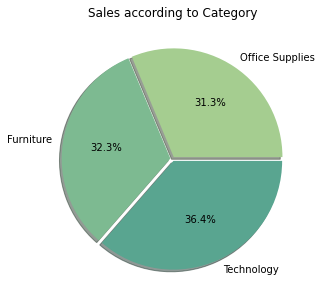

```python
sales_cat=df.groupby('Category')['Sales'].sum().reset_index().sort_values(by=['Sales'])
df_sales_cat=pd.DataFrame(sales_cat)
print(df_sales_cat)

cmap=plt.get_cmap('crest')
colors=[cmap(i) for i in np.linspace(0,1,8)]
Labels=df_sales_cat['Category']
plt.figure(figsize=(5,5))
plt.pie(df_sales_cat['Sales'],autopct='%1.1f%%',labels=Labels,explode=(0.02,0.02,0.02),colors=colors,shadow=True)
plt.title('Sales according to Category')
plt.show()
```

Sales of Each Segments:

```
       Segment         Sales
2  Home Office  4.292117e+05
1    Corporate  7.059702e+05
0     Consumer  1.159418e+06
```

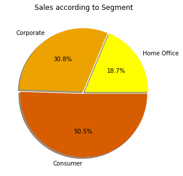

```python
sales_seg=df.groupby('Segment')['Sales'].sum().reset_index().sort_values(by=['Sales'])
df_sales_seg=pd.DataFrame(sales_seg)
print(df_sales_seg)

cmap=plt.get_cmap('gnuplot_r')
colors=[cmap(i) for i in np.linspace(0,1,8)]
Labels=df_sales_seg['Segment']
plt.figure(figsize=(5,5))
plt.pie(df_sales_seg['Sales'],autopct='%1.1f%%',labels=Labels,explode=(0.02,0.02,0.02),colors=colors,shadow=True)
plt.title('Sales according to Segment')
plt.show()
```

Sales in each Region:

```
    Region        Sales
2    South  391721.9050
0  Central  500724.2708
1     East  677843.9080
3     West  724309.2935
```

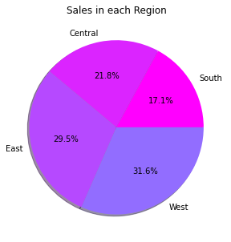

```python
Sales_reg=df.groupby('Region')['Sales'].sum().reset_index().sort_values(by='Sales')
df_Sales_reg=pd.DataFrame(Sales_reg)
print(df_Sales_reg)
cmap=plt.get_cmap('cool_r')
colors=[cmap(i) for i in np.linspace(0,1,8)]
Labels=df_Sales_reg['Region']
plt.figure(figsize=(5,5))
plt.pie(df_Sales_reg['Sales'],autopct='%1.1f%%',colors=colors,labels=Labels,shadow=True)
plt.title("Sales in each Region")
plt.show()
```

Sales of each Sub-Category:

```
   Sub-Category        Sales
13       Phones  329704.6780
5        Chairs  327777.7610
14      Storage  223808.4400
16       Tables  206965.5320
3       Binders  203328.8590
11     Machines  189238.6310
0   Accessories  167303.3020
6       Copiers  149528.0300
4     Bookcases  114166.9293
1    Appliances  107532.1610
9   Furnishings   91658.4440
12        Paper   77960.8940
15     Supplies   46673.5380
2           Art   27065.7320
7     Envelopes   16476.4020
10       Labels   12385.7640
8     Fasteners    3024.2800
```

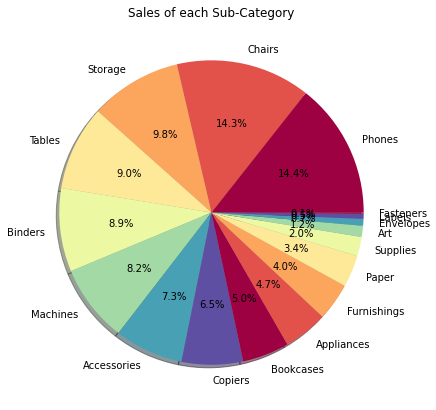

```python
Sales_SC=df.groupby('Sub-Category')['Sales'].sum().reset_index().sort_values(by='Sales',ascending=False)
df_Sales_SC=pd.DataFrame(Sales_SC)
print(df_Sales_SC)
cmap=plt.get_cmap('Spectral')
Labels=df_Sales_SC['Sub-Category']
colors=[cmap(i) for i in np.linspace(0,1,8)]
plt.figure(figsize=(7,7))
plt.pie(df_Sales_SC['Sales'],autopct='%1.1f%%',labels=Labels,colors=colors,shadow=True)
plt.title('Sales of each Sub-Category')
plt.show()
```

Top 15 cities with highest sales:

```
              City        Sales
329  New York City  255841.1050
266    Los Angeles  175296.8170
452        Seattle  119460.2820
438  San Francisco  112184.8130
374   Philadelphia  108948.1090
207        Houston   64422.7704
80         Chicago   48500.8090
437      San Diego   47502.1290
216   Jacksonville   44713.1830
464    Springfield   43054.3420
123        Detroit   42056.9740
94        Columbus   38424.8710
330         Newark   28576.1190
93        Columbia   25283.3240
233      Lafayette   25036.2000
```

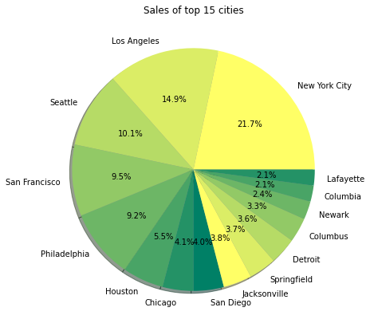

```python
Sales_City=Sales_City=df.groupby('City')['Sales'].sum().reset_index().sort_values(by='Sales',ascending=False)
df_Sales_City=pd.DataFrame(Sales_City)
top15_cities=df_Sales_City.head(15)
print(top15_cities)
cmap=plt.get_cmap('summer_r')
Labels=top15_cities['City']
colors=[cmap(i) for i in np.linspace(0,1,8)]
plt.figure(figsize=(7,7))
plt.pie(top15_cities['Sales'],autopct='%1.1f%%',labels=Labels,colors=colors,shadow=True)
plt.title('Sales of top 15 cities')
plt.show()
```

Top 15 States with Highest Sales:

```
             State        Sales
3       California  456629.9285
30        New York  310349.2150
41           Texas  170101.1278
45      Washington  138560.8100
36    Pennsylvania  116383.0100
8          Florida   89473.7080
11        Illinois   80127.3690
33            Ohio   77976.7640
20        Michigan   75879.6440
44        Virginia   70636.7200
31  North Carolina   55603.1640
12         Indiana   53555.3600
9          Georgia   49095.8400
15        Kentucky   36591.7500
28      New Jersey   35764.3120
```

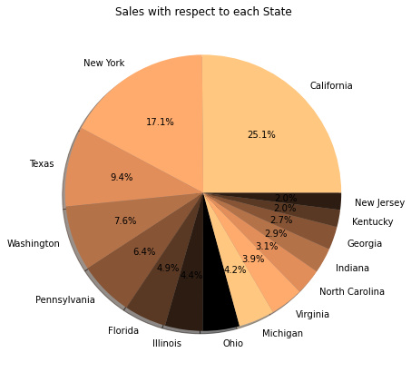

```python
Sales_state=df.groupby('State')['Sales'].sum().reset_index().sort_values(by='Sales',ascending=False)
df_Sales_state=pd.DataFrame(Sales_state)
top15_states=df_Sales_state.head(15)
print(top15_states)
cmap=plt.get_cmap('copper_r')
Labels=top15_states['State']
colors=[cmap(i) for i in np.linspace(0,1,8)]
plt.figure(figsize=(7,7))
plt.pie(top15_states['Sales'],autopct='%1.1f%%',colors=colors,shadow=True,labels=Labels)
plt.title('Sales with respect to each State')
plt.show()
```